# Introduction to SBM and LBM. Practice

Sophie Donnet & Sarah Ouadah

18 janvier 2019

# Dataset : fungus-tree interactions

VACHER, C., PIOU, D. and DESPREZ-LOUSTAU, M.-L. (2008). Architecture of an antagonistic tree/fungus network: The asymmetric influence of past evolutionary history. PLoS ONE 3 1740.

```r
rm(list=ls())
load('../data/fungi_tree_data.Rdata')
ls()
```

```
## [1] "fungi_list" "fungi_tree" "ListVar"    "tree"       "tree_bin"
## [6] "tree_list"
```

- $154$ fungi species, $51$ tree species
- “fungi_list”: list of fungal species names
- “tree_list” : list of trees species names
- “tree_bin” : binary tree-tree interactions ($1$ if hosting at least one common fungal species, $0$ otherwise)
- “tree” : weighted tree-tree interactions (number of common fungal species two tree species host)
- “ListVar” : covariates discribing pairs of trees (genetic, taxonomic and geographic distances)
- “fungi_tree” : binary fungus-tree interactions

# Useful packages

- R-package blockmodels to infer Stochastic Block Model [SBM] and Latent Block model [LBM] on ecological networks
- We will also need the ggplot2, igraph and alluvial packages.

```r
library(blockmodels)
library(igraph)
library(alluvial)
library(ggplot2)
```

- For this class, we wrote additional ad-hoc functions. They are in the following file:

```r
source('function_for_blockmodels.R')
```

# Stochastic Block Model for Binary Network

## Dataset : binary tree-tree interactions

We consider that two trees are in interaction if they host at least one common fungal species.

- Plot of the adjacency matrix:

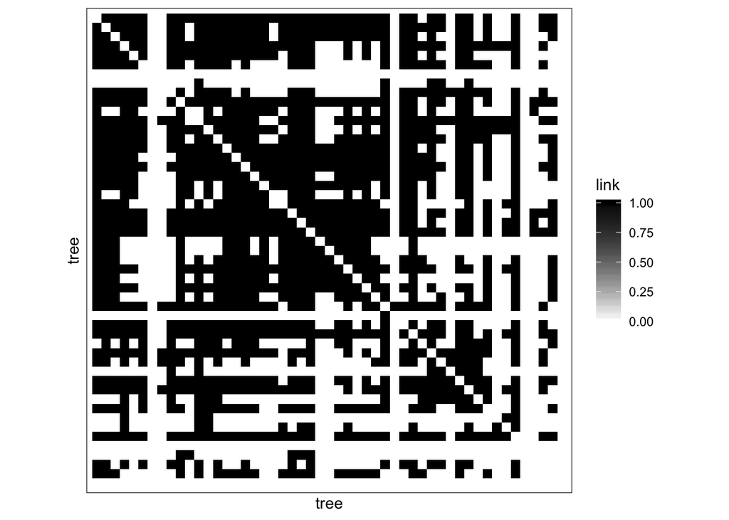

```r
plotMatrix(Mat = tree_bin,rowFG = 'tree', colFG  = 'tree')
```

## Model and inference

$$\begin{align*}
(Z_i) \text{ i.i.d.} \qquad & Z_i \sim \mathcal{M}(1, \pi) \\
(Y_{ij}) \text{ indep.} \mid (Z_i) \qquad & (Y_{ij} \mid Z_i=k, Z_j = \ell) \sim \mathcal{B}(\alpha_{k\ell})
\end{align*}$$

- Blockmodel : object programming
- First we define the object

```r
sbm.tree_bin <- BM_bernoulli("SBM_sym",tree_bin)
```

“SBM_sym”" indicates that the adjacency is symmetric (undirected network), it is important to specify it for statistical reasons. If the matrix is nonsymmetric (directed network), we use BM_bernoulli(“SBM”,tree_bin) instead.

- Then we apply the inference method

```r
sbm.tree_bin$estimate()
```

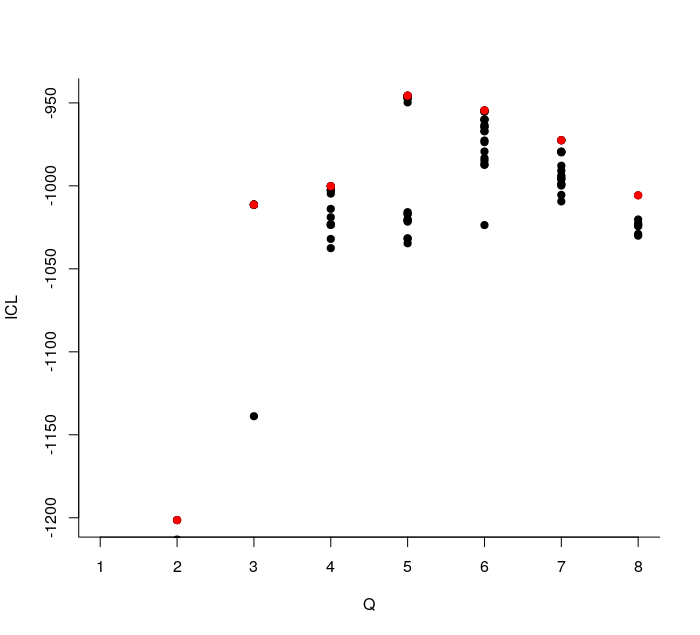

- The various points correspond to several runs of the estimation (resulting into a model selection criteria value) for a given number of clusters (denoted $Q$ here).
- We select the best number of clusters (with respect to the ICL criteria).

```r
Q = which.max(sbm.tree_bin$ICL)
Q
```

```
## [1] 5
```

- We can now extract the parameters of interest, namely ($\alpha$, $\pi$) and the nodes (here tree species) clustering $Z$

```r
paramEstimSBM <- extractParamBM(sbm.tree_bin,Q)
paramEstimSBM$pi
```

```
## [1] 0.1766999 0.2349327 0.1573006 0.2737836 0.1572832
```

```r
paramEstimSBM$alpha
```

```
##            [,1]      [,2]       [,3]       [,4]       [,5]
## [1,] 0.02899357 0.1718985 0.07366695 0.07110948 0.01981535
## [2,] 0.17189850 0.9652552 0.82888903 0.99609554 0.39032528
## [3,] 0.07366695 0.8288890 0.46398566 0.58170318 0.08766891
## [4,] 0.07110948 0.9960955 0.58170318 0.99641693 0.97606402
## [5,] 0.01981535 0.3903253 0.08766891 0.97606402 0.77765335
```

```r
paramEstimSBM$Z
```

```
##  [1] 4 4 4 2 2 3 1 1 3 4 3 2 2 2 4 4 4 4 5 3 5 4 4 4 5 5 5 4 5 4 5 2 1 2 4
## [36] 3 2 3 1 2 2 3 2 1 1 2 1 1 3 5 1
```

- One can plot the reorganized matrix according to the clustering.

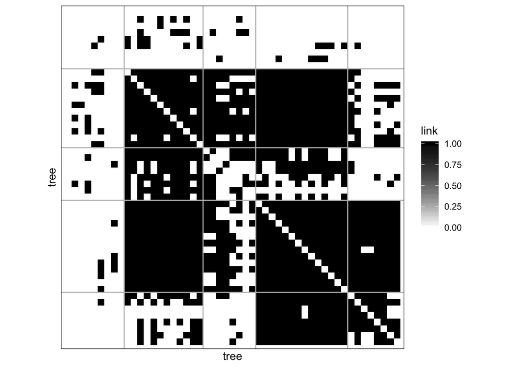

```r
plotMatrix(tree_bin,'tree','tree', fileNameSave = NULL, clustering = list(row=paramEstimSBM$Z))
```

- Finally one can plot the macroview of the network.

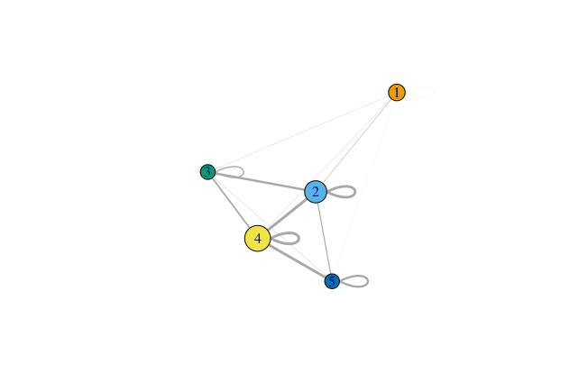

```r
G <- graph_from_adjacency_matrix(paramEstimSBM$alpha, mode = c("undirected"), weighted = TRUE, diag = TRUE)
plot.igraph(G,vertex.size=paramEstimSBM$pi*100,edge.width=abs(E(G)$weight)*3,vertex.color=1:Q, layout=layout_nicely)
```

- The composition of the clusters/blocks are given by:

```r
lapply(1:Q,function(q){tree_list[paramEstimSBM$Z == q]})
```

```
## [[1]]
## [1] Betulus spp (Betula pendula, Betula pubescens)
## [2] Carpinus betulus
## [3] Populus tremula
## [4] Quercus pyrenaica
## [5] Sorbus aucuparia
## [6] Sorbus domestica
## [7] Taxus baccata
## [8] Thuja plicata
## [9] Ulmus spp (Ulmus minor, Ulmus laevis, Ulmus glabra)
## 51 Levels: Abies alba Abies grandis Abies nordmanniana ... Ulmus spp (Ulmus minor, Ulmus laevis, Ulmus glabra)
##
## [[2]]
##  [1] Large Maples (Acer platanoides, Acer pseudoplatanus)
##  [2] Small Maples (Acer campestre, Acer monspessulanum, Acer negundo, Acer opalus)
```

[output cut: 50 more lines]

# SBM for Counting Network

## Dataset : weighted tree-tree interactions

In the weighted tree-tree interactions network, each edge is valued with the number of common fungal species two tree species can host.

- Plot of the adjacency matrix:

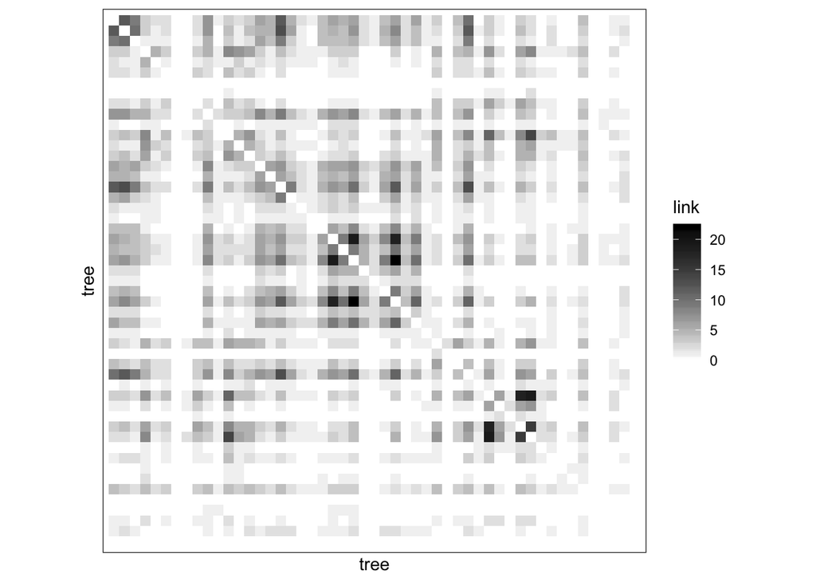

```r
plotMatrix(Mat = tree,rowFG = 'tree', colFG  = 'tree')
```

## Model and inference

We consider the SBM Poisson model.

$$\begin{align*}
(Z_i) \text{ i.i.d.} \qquad & Z_i \sim \mathcal{M}(1, \pi) \\
(Y_{ij}) \text{ indep.} \mid (Z_i) \qquad & (Y_{ij} \mid Z_i=k, Z_j = \ell) \sim \mathcal{P}(\exp(\alpha_{kl})) = \mathcal{P}(\lambda_{kl})
\end{align*}$$

```r
sbm.tree <- BM_poisson("SBM_sym",tree)
```

- Then we apply the inference method

```r
sbm.tree$estimate()
```

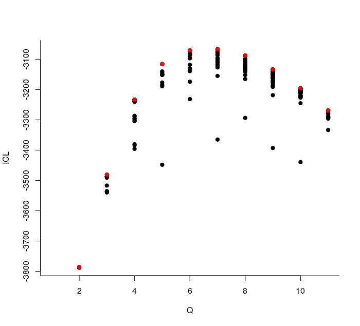

- We select the best number of clusters (with respect to the ICL criteria)

```r
Q = which.max(sbm.tree$ICL)
Q
```

```
## [1] 7
```

- We can now extract the parameters of interest, namely ($\lambda$, $\pi$) and the clustering of the nodes.

```r
paramEstimSBMPoisson <- extractParamBM(sbm.tree,Q)
paramEstimSBMPoisson$pi
```

```
## [1] 0.19535504 0.07930706 0.13733105 0.13737914 0.17596562 0.15667238
## [7] 0.11798972
```

```r
paramEstimSBMPoisson$lambda
```

```
##            [,1]       [,2]      [,3]       [,4]      [,5]       [,6]
## [1,] 0.04618822  0.5380801 0.1359095 0.06433233 0.1001196 0.02087243
## [2,] 0.53808015 13.4631412 3.0510918 1.25957821 3.5729222 0.50401137
## [3,] 0.13590946  3.0510918 0.8582246 0.45867398 1.2185496 0.16005693
## [4,] 0.06433233  1.2595782 0.4586740 3.94160911 6.0476961 1.46256130
## [5,] 0.10011961  3.5729222 1.2185496 6.04769607 9.0299656 1.85466750
## [6,] 0.02087243  0.5040114 0.1600569 1.46256130 1.8546675 0.54121406
## [7,] 0.26457217  4.9737771 1.7507213 1.40183061 3.1042204 0.50118123
##           [,7]
## [1,] 0.2645722
## [2,] 4.9737771
## [3,] 1.7507213
## [4,] 1.4018306
## [5,] 3.1042204
## [6,] 0.5011812
## [7,] 4.2428566
```

```r
paramEstimSBMPoisson$Z
```

```
##  [1] 5 5 4 7 3 3 1 1 3 5 6 2 7 7 5 4 5 4 6 6 4 5 4 5 6 6 4 5 6 4 6 7 1 7 5
## [36] 3 2 3 1 2 2 1 3 1 1 7 1 1 3 6 1
```

- One can plot the reorganized matrix according to the clustering.

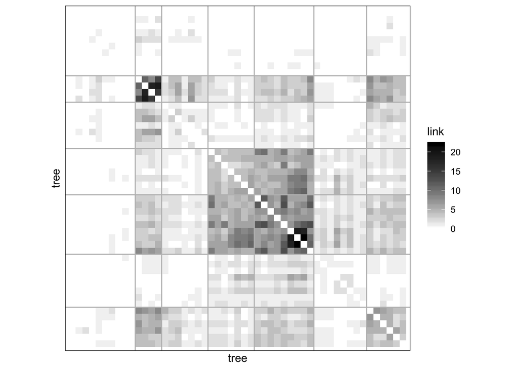

```r
plotMatrix(tree,'tree','tree', fileNameSave = NULL, clustering = list(row=paramEstimSBMPoisson$Z))
```

- One can plot the macroview of the network.

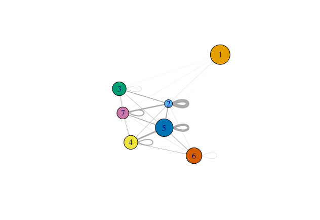

```r
G <- graph_from_adjacency_matrix(paramEstimSBMPoisson$lambda, mode = c("undirected"), weighted = TRUE, diag = TRUE)
plot.igraph(G,vertex.size=paramEstimSBMPoisson$pi*100,edge.width=abs(E(G)$weight)*3,vertex.color=1:Q, layout=layout_nicely)
```

- The composition of the clusters/blocks are given by :

```r
lapply(1:Q,function(q){tree_list[paramEstimSBMPoisson$Z == q]})
```

```
## [[1]]
##  [1] Betulus spp (Betula pendula, Betula pubescens)
##  [2] Carpinus betulus
##  [3] Populus tremula
##  [4] Quercus pyrenaica
##  [5] Quercus suber
##  [6] Sorbus aucuparia
##  [7] Sorbus domestica
##  [8] Taxus baccata
##  [9] Thuja plicata
## [10] Ulmus spp (Ulmus minor, Ulmus laevis, Ulmus glabra)
## 51 Levels: Abies alba Abies grandis Abies nordmanniana ... Ulmus spp (Ulmus minor, Ulmus laevis, Ulmus glabra)
##
## [[2]]
## [1] Fagus silvatica Quercus petraea Quercus robur   Quercus rubra
```

[output cut: 49 more lines]

We are interested in comparing the two cluterings. To do so we use the alluvial flow plots.

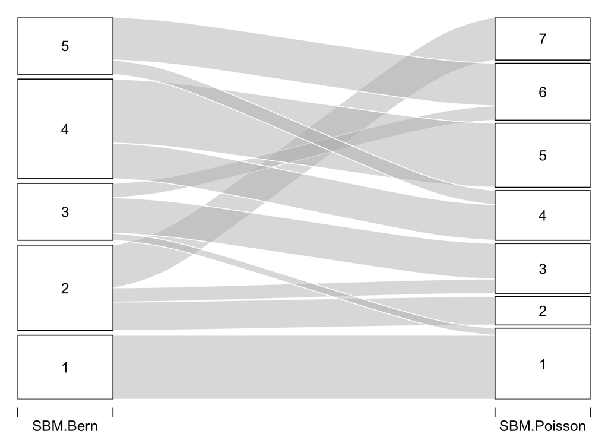

```r
A <- as.data.frame(table(paramEstimSBM$Z,paramEstimSBMPoisson$Z))
colnames(A)=c('SBM Bern',"SBM Poisson","Freq")
w   <- which(A$Freq!=0)
A <- A[w,]
alluvial(A[,c(1,2)],freq=A$Freq)
```

# SBM for Counting Network with covariates

## Dataset : weighted tree-tree interactions with covariates

We have on each pair of trees 3 covariates, namely the genetic distance, the taxonomic distance and the geographic distance.

Each covariate has to be introduced as a matrix: $X^k_{ij}$ corresponds to the value of the $k$-th covariate describing the couple $(i,j)$.

## Model and inference

We can also use the Blockmodels package to estimate the parameters described previously.

$$\begin{align*}
(Z_i) \text{ i.i.d.} \qquad & Z_i \sim \mathcal{M}(1, \pi) \\
(Y_{ij}) \text{ indep.} \mid (Z_i) \qquad & (Y_{ij} \mid Z_i=k, Z_j = \ell) \sim \mathcal{P}(\exp(\alpha_{kl} + x_{ij}^\intercal \beta)) = \mathcal{P}(\lambda_{kl}\exp(x_{ij}^\intercal \beta))
\end{align*}$$

```r
sbm.cov <- BM_poisson_covariates("SBM_sym",tree, ListVar)
sbm.cov$estimate()
```

- We select the best number of clusters (with respect to the ICL criteria)

```r
Q = which.max(sbm.cov$ICL)
Q
```

```
## [1] 4
```

- We can now extract the parameters of interest, namely ($\lambda$, $\pi$) and the clustering of the nodes.

```r
paramEstimSBMPoissonCov <- extractParamBM(sbm.cov,Q)
paramEstimSBMPoissonCov$pi
```

```
## [1] 0.3715916 0.2159544 0.2354118 0.1770422
```

```r
paramEstimSBMPoissonCov$lambda
```

```
##           [,1]       [,2]      [,3]      [,4]
## [1,] 28.195865 14.8906707 5.9595874 1.2392524
## [2,] 14.890500  9.5613930 3.7926806 0.4101331
## [3,]  5.960314  3.7926863 1.6185496 0.3841997
## [4,]  1.239193  0.4101441 0.3842595 0.1893057
```

```r
paramEstimSBMPoissonCov$Z
```

```
##  [1] 1 1 2 1 2 2 4 4 2 1 3 1 1 1 1 2 1 2 3 3 2 1 2 1 3 3 2 1 3 2 3 1 4 1 1
## [36] 3 1 3 4 1 1 3 2 4 4 1 4 4 3 3 4
```

```r
paramEstimSBMPoissonCov$beta
```

```
##            [,1]
## [1,]  0.1976031
## [2,] -2.0549368
## [3,] -0.3583543
```

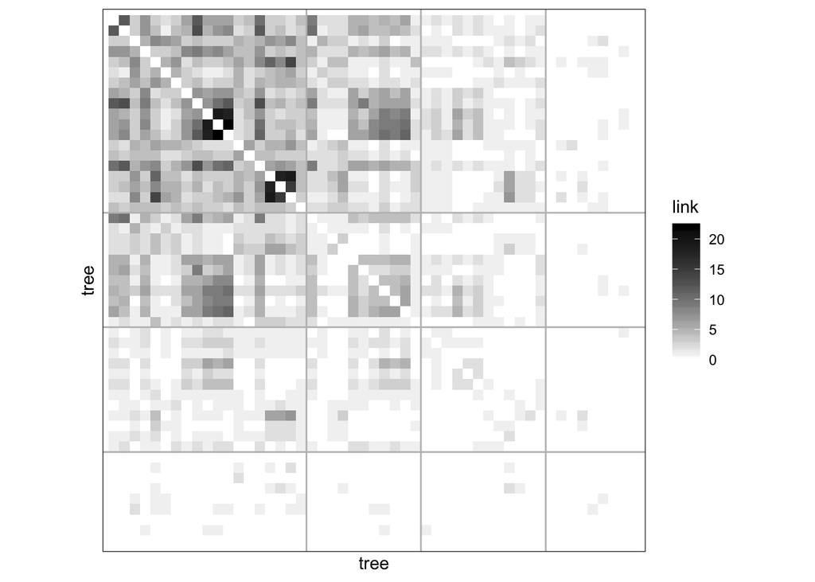

```r
plotMatrix(tree,'tree','tree', fileNameSave = NULL, clustering = list(row=paramEstimSBMPoissonCov$Z))
```

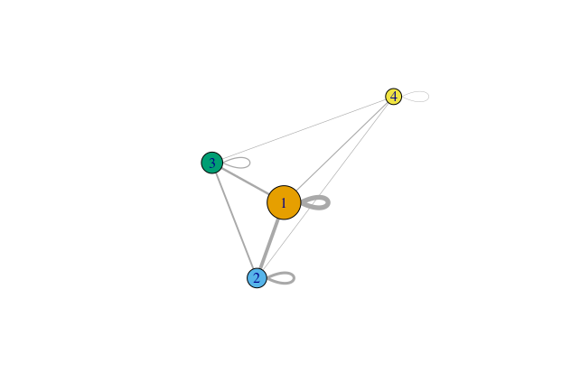

```r
G <- graph_from_adjacency_matrix(paramEstimSBMPoissonCov$lambda, mode = c("undirected"), weighted = TRUE, diag = TRUE)
plot.igraph(G,vertex.size = paramEstimSBMPoissonCov$pi*100,edge.width=sqrt(abs(E(G)$weight)),vertex.color = 1:Q, layout = layout_nicely)
```

- The composition of the clusters/blocks are given by:

```r
lapply(1:Q,function(q){tree_list[paramEstimSBMPoissonCov$Z == q]})
```

```
## [[1]]
##  [1] Abies alba
##  [2] Abies grandis
##  [3] Large Maples (Acer platanoides, Acer pseudoplatanus)
##  [4] Cedrus spp (Cedrus atlantica, Cedrus libani)
##  [5] Fagus silvatica
##  [6] Fraxinus spp (Fraxinus angustifolia, Fraxinus excelsior)
##  [7] Juglans spp (Juglans nigra, Juglans regia)
##  [8] Larix decidua
##  [9] Picea excelsa
## [10] Pinus nigra laricio
## [11] Pinus pinaster
## [12] Pinus sylvestris
## [13] Cultivated Poplars (Populus trichocarpa, P. canescens, P.alba, P.nigra and their cultivated hybrids)
## [14] Prunus avium
```

[output cut: 47 more lines]

We are interested in comparing the three cluterings. To do so we use the alluvial flow plots

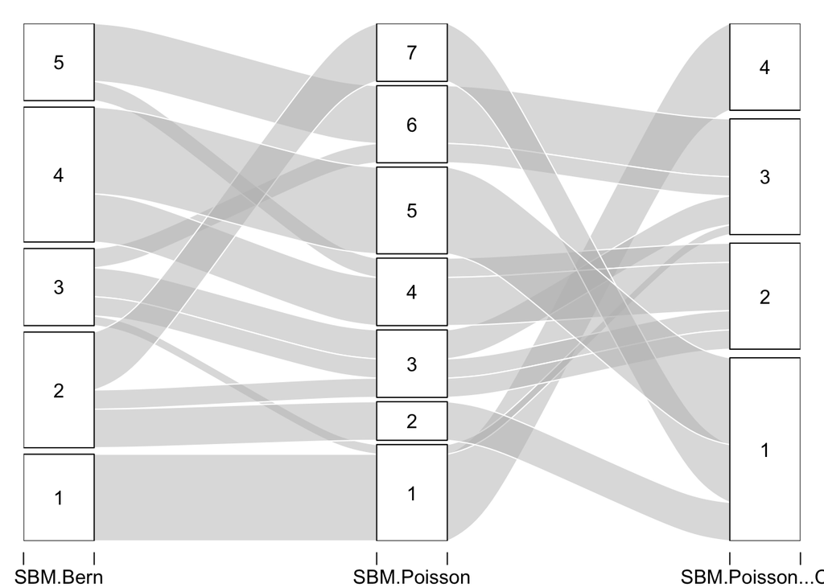

```r
B <- as.data.frame(table(paramEstimSBM$Z,paramEstimSBMPoisson$Z,paramEstimSBMPoissonCov$Z))
colnames(B) = c('SBM Bern',"SBM Poisson","SBM Poisson + Cov","Freq")
w   <- which(B$Freq!=0)
B <- B[w,]
alluvial(B[,c(1,2,3)],freq=B$Freq)
```

# Latent Block model

## Dataset : fungus-tree interactions

In the fungi-tree interactions network, an edge indicates if a tree species host a fungal species.

- Plot of the incidence matrix

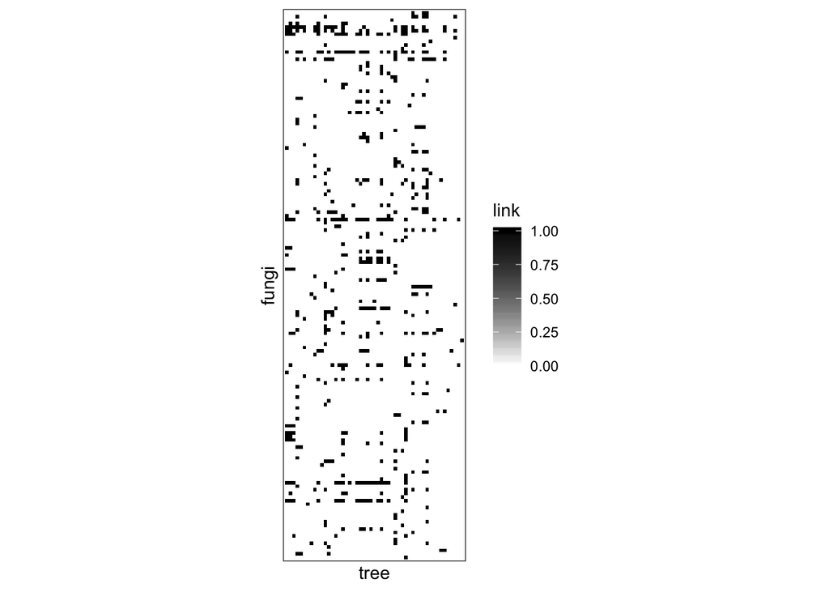

```r
plotMatrix(Mat = fungi_tree,rowFG = 'fungi', colFG  = 'tree')
```

We can know try to get a clustering of fungus and tree species conjointly.

## Model and inference

$$\begin{align*}
(Z^R_i) \text{ i.i.d.} \qquad & Z^R_i \sim \mathcal{M}(1, \pi^R) \\
(Z^C_i) \text{ i.i.d.} \qquad & Z^C_i \sim \mathcal{M}(1, \pi^C) \\
(Y_{ij}) \text{ indep.} \mid (Z^R_i, Z^C_j) \qquad & (Y_{ij} \mid Z^R_i=k, Z^C_j = \ell) \sim \mathcal{B}(\alpha_{k\ell})
\end{align*}$$

```r
lbm <- BM_bernoulli("LBM",as.matrix(fungi_tree))
lbm$estimate()
```

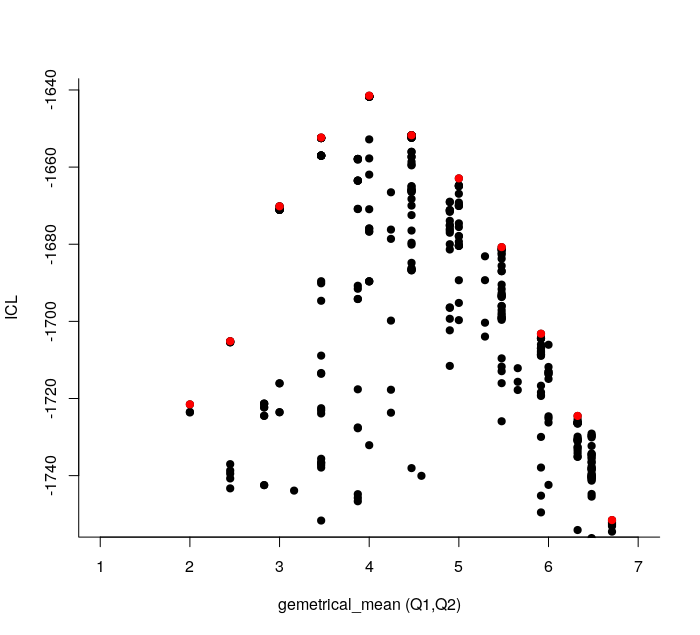

- We select the best number of clusters (with respect to the ICL criteria)

```r
Q = which.max(lbm$ICL)
Q
```

```
## [1] 8
```

```r
paramEstimLBM <- extractParamBM(lbm,Q)
paramEstimLBM$Q
```

```
## QRow QCol
##    4    4
```

- We can extract the parameters of interest, namely ($\alpha$, $\pi$) and the clustering of the nodes.

```r
paramEstimLBM$piRow
```

```
## [1] 0.31666508 0.60107642 0.02655516 0.05570334
```

```r
paramEstimLBM$piCol
```

```
## [1] 0.1963968 0.1050494 0.4508234 0.2477304
```

```r
paramEstimLBM$alpha
```

```
##             [,1]       [,2]        [,3]        [,4]
## [1,] 0.003624764 0.32450427 0.005780612 0.098526840
## [2,] 0.154334411 0.01834547 0.019219920 0.001330278
## [3,] 0.077538579 0.96813478 0.067563355 0.840370657
## [4,] 0.584398216 0.52055882 0.107930384 0.230893917
```

```r
paramEstimLBM$ZRow
```

```
##   [1] 2 2 2 1 4 4 3 2 2 2 2 4 2 4 1 1 1 1 2 2 1 1 1 2 2 1 2 1 1 2 2 2 2 2 1
##  [36] 1 1 2 1 2 2 2 2 2 2 2 2 4 4 2 2 2 2 2 1 2 4 1 3 2 1 2 1 1 2 1 1 1 1 1
##  [71] 1 2 1 2 2 1 2 2 2 2 2 1 2 1 2 2 2 1 2 2 4 1 2 2 2 1 2 1 1 4 1 1 2 1 2
## [106] 2 2 2 2 2 2 2 2 2 2 2 1 1 1 1 1 1 2 2 1 2 2 2 2 2 1 1 3 2 2 1 2 3 2 2
## [141] 2 2 2 2 2 1 2 1 2 2 2 2 2 1
```

```r
paramEstimLBM$ZCol
```

```
##  [1] 4 4 4 1 3 3 3 3 1 4 3 1 1 1 4 4 2 4 3 3 4 2 4 2 4 3 4 2 4 4 3 1 3 1 2
## [36] 3 1 3 3 1 1 3 3 3 3 3 3 3 3 3 3
```

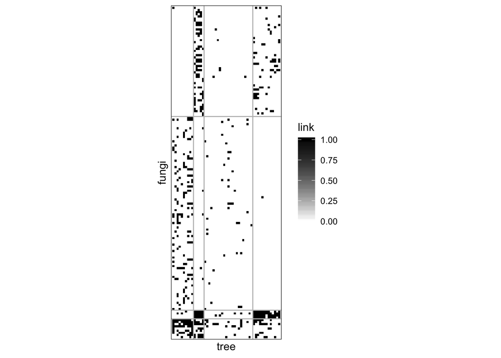

```r
plotMatrix(fungi_tree,'fungi','tree', fileNameSave = NULL, clustering = list(row = paramEstimLBM$ZRow,col = paramEstimLBM$ZCol))
```

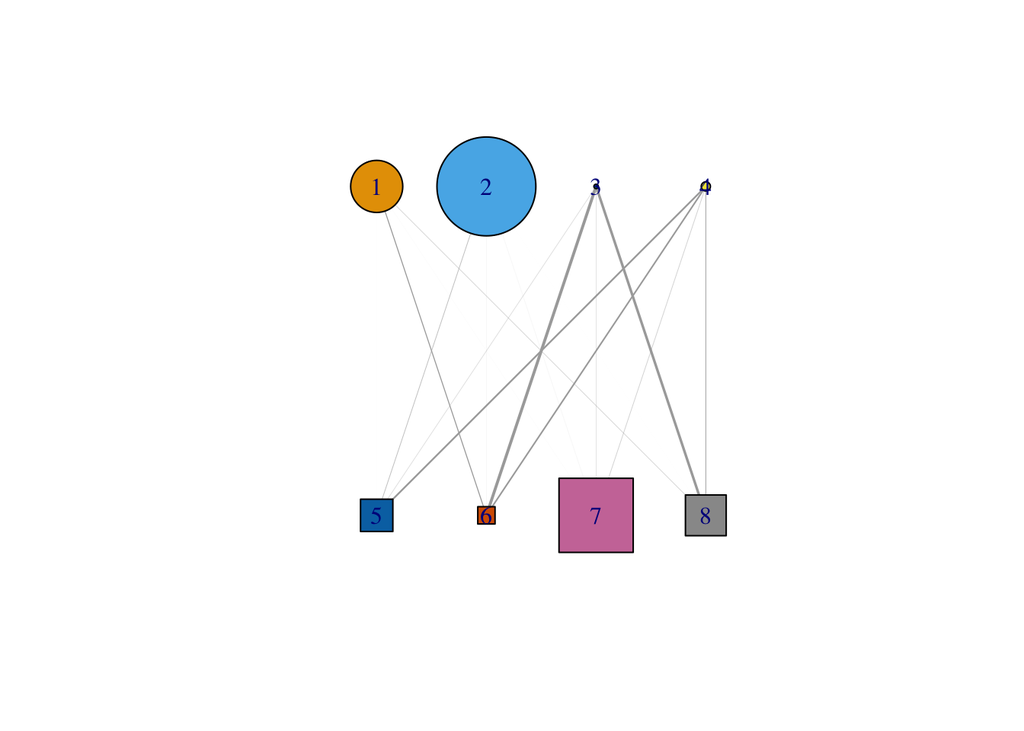

```r
G <- graph_from_incidence_matrix(paramEstimLBM$alpha, weighted = TRUE)
plot(G,vertex.size=c(paramEstimLBM$piRow*100, paramEstimLBM$piCol*100), vertex.shape=c("circle", "square")[V(G)$type +1], edge.width=abs(E(G)$weight*2),vertex.color=1:Q, layout=layout.bipartite)
```

- Exercise : give the name list of the various clusters.